# R Notebook

This notebook

- reads CPA-generated CSV files
- combines and filters them
- cleans up
- creates SQLite files that can be read by CPA, in a way that images with the same channel set are batched together
- downloads the image files to the right location

Environment

- Windows machine
- AWS credentials are set up
- Lots of luck

```r
install.packages("magrittr")
install.packages("tidyverse")
install.packages("rmarkdown")
install.packages("RSQLite")
install.packages("glue")
install.packages("arrow")
install.packages("doParallel")
```

```r
library(magrittr)
library(tidyverse)
library(RSQLite)
library(glue)
library(arrow)
library(doParallel)
library(foreach)
```

```r
registerDoParallel()
```

```r
set.seed(42)
```

`setname` is the name of directory on the Desktop that contains the CSV files

Be sure to delete the `*.sqlite` files by hand

[output not shown]

```r
setname <- "DavidPearlQCFixed_6channel"
```

Specify the Windows drive where files will be downloaded

```r
destination_windows_drive <- "D:\\"
```

Specify whether to randomly sample (TRUE when testing downloads)

```r
randomly_sample <- FALSE
```

Download nd2 files or non-nd2 files

```r
nd2 <- FALSE
```

Specify how to fix Nikon paths to point to location of tifs

```r
nikon_fix_posix <- function(x) str_replace(x, "2020_11_24_Scope1_Nikon", "2020_11_24_Scope1_Nikon/tifs")
nikon_fix_windows <- function(x) str_replace(x, "2020_11_24_Scope1_Nikon", "2020_11_24_Scope1_Nikon\\\\tifs")
```

```r
setname_output_suffix <- ifelse(nd2, "only_nd2", "exclude_nd2")
setname_output <- paste(setname, setname_output_suffix, sep = "_")
```

```r
if (Sys.info()['sysname'] == "Darwin") {
  output_dir <- "~/Desktop"
  image_output_dir <- normalizePath("~/work/projects/2019_07_11_JUMP-CP")
} else if (Sys.info()['sysname'] == "Linux") {
  output_dir <- "/dgx1nas1/cellpainting-datasets/2019_07_11_JUMP_CP_pilots/workspace/qc_postprocessing"
  image_output_dir <- normalizePath("/dgx1nas1/cellpainting-datasets/2019_07_11_JUMP-CP")
} else {
  output_dir <- "C:/Users/Administrator/Desktop"
  image_output_dir <- "D:"
  destination_windows_drive <- paste0(image_output_dir, "\\")
}
```

Your `~/.aws/credentials` should contain `jump-cellpainting` account credentials as the default profile

```
[default]
aws_access_key_id = XXXX
aws_secret_access_key = XXXX
```

```bash
output_dir=~/Desktop #OSX (for testing only)
#output_dir=/dgx1nas1/cellpainting-datasets/2019_07_11_JUMP_CP_pilots/workspace/qc_postprocessing #Linux
output_dir=C:/Users/Administrator/Desktop #Windows
setname=DavidPearlQCFixed_6channel
aws s3 cp --no-progress s3://jump-cellpainting/projects/2019_07_11_JUMP-CP-pilots/workspace/qc_postprocessing/${setname}.zip ${output_dir}
rm -rf ${output_dir}/${setname}
mkdir ${output_dir}/${setname}
unzip ${output_dir}/${setname}.zip -d ${output_dir}/${setname}
```

```
download: s3://jump-cellpainting/projects/2019_07_11_JUMP-CP-pilots/workspace/qc_postprocessing/DavidPearlQCFixed_6channel.zip to ..\..\..\..\Desktop\DavidPearlQCFixed_6channel.zip
Archive:  C:/Users/Administrator/Desktop/DavidPearlQCFixed_6channel.zip
  inflating: C:/Users/Administrator/Desktop/DavidPearlQCFixed_6channel/Classifier_Plate2-PCO-6ch-4site-10XPA_David.csv
```

```r
list.files(glue("{output_dir}/{setname}/"), full.names = T, pattern = "*.csv")
```

```
[1] "C:/Users/Administrator/Desktop/DavidPearlQCFixed_6channel/Classifier_Plate2-PCO-6ch-4site-10XPA_David.csv"
```

Read them into a parquet file (for efficiency)

```r
parquet_file <- glue("{output_dir}/{setname}.parquet")

if (file.exists(parquet_file)) {
  df <- arrow::read_parquet(parquet_file)

} else {
  df <-
    list.files(glue("{output_dir}/{setname}/"), full.names = T, pattern = "*.csv") %>%
    map_df(
      read_csv,
      col_types = cols(Image_Metadata_Plate = col_character(), PlateID = col_character())
    )

  df %>% arrow::write_parquet(parquet_file)

}
```

Filter down to only the rows you care about

```r
df %<>% filter(UserAnnotation_Debris == 1)
```

Pick nd2 files or other files

```r
any_filename <- str_subset(names(df), "Image_URL_")[[1]]

if (!nd2) {
  df %<>% filter(!str_detect(.data[[any_filename]], "nd2"))
} else {
  df %<>% filter(str_detect(.data[[any_filename]], "nd2"))
}
```

Random sample (optional)

```r
if(randomly_sample) {
  df %<>% sample_n(3)
}
```

Fix wells

```r
df %<>%
  mutate(Image_Metadata_Well =
           ifelse(is.na(Image_Metadata_Well),
                  Image_Metadata_Well_x,
                  Image_Metadata_Well)
  )
```

Change the URL to S3

```r
s3ify  <- function(x) {
  if (is.na(x)) {
    NA
  } else {
    str_replace(x, "file:", "s3:/") %>% str_replace_all("\\\\", "/")  %>% str_replace_all("home/ubuntu/bucket", "jump-cellpainting") %>% URLdecode()
  }
}


df %<>% rowwise() %>% mutate(across(matches("URL"), s3ify)) %>% ungroup()
```

Fix URLs

```r
channel_names <- names(df) %>% str_subset("URL") %>% str_remove_all("Image_URL_")

for (channel_name in channel_names) {
  filename_column <- glue("Image_FileName_{channel_name}")

  url_column <- glue("Image_URL_{channel_name}")

  df[[url_column]] <-
    mapply(function(url_column_i,
                    filename_column_i)
      if (is.na(url_column_i)) {
        NA
      }
      else {
        paste(
          URLdecode(dirname(url_column_i)),
          URLdecode(filename_column_i),
          sep = "/")
      },
      df[[url_column]],
      df[[filename_column]]) %>%
    unname()
}
```

Force the drive to be wherever you plan to down the files on the Windows machine

```r
drive_fix <- function(x) str_replace(x, "^[A-Z]:\\\\", destination_windows_drive)

df %<>% rowwise() %>% mutate(across(matches("Image_PathName"), drive_fix)) %>% ungroup()
```

Fix paths for the Nikon images

```r
df %<>% rowwise() %>% mutate(across(matches("Image_PathName"), nikon_fix_windows)) %>% ungroup()

df %<>% rowwise() %>% mutate(across(matches("Image_URL"), nikon_fix_posix)) %>% ungroup()
```

Save as a set of SQLite files

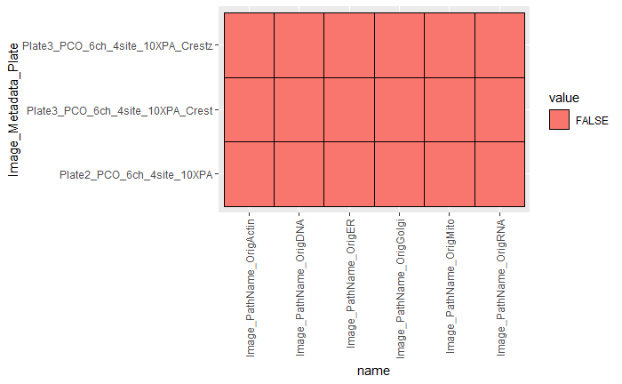

```r
channels <-
  df %>%
  select(Image_Metadata_Plate, matches("PathName")) %>%
  mutate(across(matches("PathName"), ~is.na(.))) %>%
  distinct()

channels %<>%
  pivot_longer(-Image_Metadata_Plate) %>%
  filter(!value) %>% select(-value) %>%
  arrange(Image_Metadata_Plate, name) %>%
  group_by(Image_Metadata_Plate) %>%
  summarise(Image_Metadata_Group = paste(name, collapse = "_"), .groups = "keep") %>%
  ungroup() %>%
  inner_join(channels) %>%
  arrange(Image_Metadata_Group) %>%
  mutate(Image_Metadata_Group = str_remove_all(Image_Metadata_Group, "Image_PathName_Orig"))
channels %>%
  pivot_longer(-any_of(c("Image_Metadata_Plate", "Image_Metadata_Group"))) %>%
  ggplot(aes(name, Image_Metadata_Plate, fill = value)) +
  geom_tile(color = "black") +
  theme(axis.text.x = element_text(angle = 90, vjust = 0.5, hjust=1))
```

```r
channels %>% group_by(Image_Metadata_Group) %>% tally()
```

| Image_Metadata_Group | n |
| --- | --- |
| Actin_DNA_ER_Golgi_Mito_RNA | 3 |

```r
df %<>% inner_join(channels %>% select(Image_Metadata_Plate, Image_Metadata_SaraspondaGroup = Image_Metadata_Group))
```

```r
for (group in unique(df$Image_Metadata_SaraspondaGroup)) {

  sqlite_file <- glue("{output_dir}/{setname_output}_{group}.sqlite")

  if(file.exists(sqlite_file)) {
    file.remove(sqlite_file)

  }

  dfi <- df %>% filter(Image_Metadata_SaraspondaGroup == group)

  dfi$Image_Metadata_MasterIndex <- seq_along(dfi$Image_Metadata_MasterIndex)

  dfi %>% count(name = group) %>% print()

  mydb <- dbConnect(SQLite(), sqlite_file)

  dbWriteTable(mydb, setname, dfi)

  dbDisconnect(mydb)
}
```

| Actin_DNA_ER_Golgi_Mito_RNA |
| --- |
| 479 |

Save list of files to be downloaded

```r
files <-
  df %>%
  ungroup() %>%
  select(matches("Image_URL_")) %>%
  pivot_longer(everything()) %>%
  na.omit() %>%
  mutate(folder = str_remove(
    dirname(value),
    "s3://jump-cellpainting/projects/2019_07_11_JUMP-CP-pilots/"
  )) %>%
  mutate(filename = basename(value)) %>%
  mutate(prefix = dirname(value)) %>%
  select(folder, filename, object = value, prefix)
```

Create commands to create directories

```r
dirs <-
  files %>%
  distinct(folder) %>%
  mutate(mkdir = glue("mkdir -p {image_output_dir}/{folder}"))
```

Create commands to download

```r
files %<>%
  mutate(download = glue('aws s3 cp --quiet "{object}" "{image_output_dir}/{folder}/{filename}"'))
```

Create directories

```r
foreach(d=iter(dirs, by = "row"), .combine = "rbind") %dopar% {
  result = system(d$mkdir);
  data.frame(folder = d$folder, result = result)
}
```

| folder | result |
| --- | --- |
| 2020_11_06_Scope1_MolDev/images/Plate2-PCO-6ch-4site-10XPA_Plate_20092/TimePoint_1 | 0 |
| 2020_11_06_Scope1_MolDev/images/Plate3-PCO-6ch-4site-10XPA-Crest_Plate_20102/TimePoint_1 | 0 |
| 2020_11_06_Scope1_MolDev/images/Plate3-PCO-6ch-4site-10XPA-Crest-z_Plate_20105/TimePoint_1 | 0 |

Download files

```r
download_result <- foreach(d=iter(files, by = "row"), .combine = "rbind") %dopar% {
  result = system(d$download);
  data.frame(folder = d$folder, filename = d$filename, object = d$object, result = result)
}
```

```r
download_result
```

Update variables in properties file (see `data/QC*.properties` for sample files)

Examples

Typical 5-channel (DNA,ER,AGP,Mito,RNA)

```
db_sqlite_file  = C:\Users\Administrator\Desktop\DavidPearlQCFixed_AGP_DNA_ER_Mito_RNA.sqlite
image_table   = DavidPearlQCFixed
image_path_cols = Image_PathName_OrigDNA,Image_PathName_OrigER,Image_PathName_OrigAGP,Image_PathName_OrigMito,Image_PathName_OrigRNA
image_file_cols = Image_FileName_OrigDNA,Image_FileName_OrigER,Image_FileName_OrigAGP,Image_FileName_OrigMito,Image_FileName_OrigRNA
image_names = DNA,ER,AGP,Mito,RNA
image_channel_colors = blue,magenta,green,red,cyan
```

4-channel (DNA,ER,AGP,Mito)

```
db_sqlite_file  = C:\Users\Administrator\Desktop\DavidPearlQCFixed_AGP_DNA_ER_Mito.sqlite
image_table   = DavidPearlQCFixed
image_path_cols = Image_PathName_OrigDNA,Image_PathName_OrigER,Image_PathName_OrigAGP,Image_PathName_OrigMito
image_file_cols = Image_FileName_OrigDNA,Image_FileName_OrigER,Image_FileName_OrigAGP,Image_FileName_OrigMito
image_names = DNA,ER,AGP,Mito
image_channel_colors = blue,magenta,green,red
```

6-channel (DNA,ER,Actin,Golgi,Mito,RNA)

```
db_sqlite_file  = C:\Users\Administrator\Desktop\DavidPearlQCFixed_Actin_DNA_ER_Golgi_Mito_RNA.sqlite
image_table   = DavidPearlQCFixed
image_path_cols = Image_PathName_OrigDNA,Image_PathName_OrigER,Image_PathName_OrigActin,Image_PathName_OrigGolgi,Image_PathName_OrigMito,Image_PathName_OrigRNA
image_file_cols = Image_FileName_OrigDNA,Image_FileName_OrigER,Image_FileName_OrigActin,Image_FileName_OrigGolgi,Image_FileName_OrigMito,Image_FileName_OrigRNA
image_names = DNA,ER,Actin,Golgi,Mito,RNA
image_channel_colors = blue,magenta,green,red,yellow,yan
```